# Predicting Lending Club database

In this project, we are going to explore and clean the dataset, analise the data and try to make a predictive model. The main objetive will be predict if a new client of the Lending Club database will do a default or will not do it.

Before studying the database, we will import the following usefull libraries.

```python
import pandas as pd
import numpy as np
import matplotlib.pyplot as plt
import seaborn as sns
from matplotlib import rcParams
from scipy import stats

#To plot figs on jupyter
%matplotlib inline
# figure size in inches
rcParams['figure.figsize'] = 14,6
```

# 1. Exploring Data

The dataset is named `loan.csv` and is located into the data directory. Firstly, we are going to call it frome there. Then, we will check the description of each of the features to familiarize ourselves with the dataset and we will create the dependent variable 'target' based in the feature 'loan_status'.

We will establish the max_columns options for viewing all the columns of the dataframe and then we print the first rows to see if the dataset has been imported rigth.

```python
pd.set_option('display.max_columns', None)
```

```python
df = pd.read_csv('../data/loan.csv', low_memory=False)
```

```python
df['title'].value_counts().head(16)
```

```
Debt consolidation           1153293
Credit card refinancing       469691
Home improvement              137437
Other                         127714
Major purchase                 44840
Medical expenses               25388
Business                       20804
Car financing                  20526
Debt Consolidation             15763
Vacation                       14443
Moving and relocation          13800
Home buying                    12714
Consolidation                   5385
debt consolidation              4837
Debt Consolidation Loan         3804
Credit Card Consolidation       2360
Name: title, dtype: int64
```

```python
sum(df['title'].isna())
```

```
23325
```

```python
df.head()
```

|  | id | member_id | loan_amnt | funded_amnt | funded_amnt_inv | term | int_rate | installment | grade | sub_grade | emp_title | emp_length | home_ownership | annual_inc | verification_status | issue_d | loan_status | pymnt_plan | url | desc | purpose | title | zip_code | addr_state | dti | delinq_2yrs | earliest_cr_line | inq_last_6mths | mths_since_last_delinq | … |
| --- | --- | --- | --- | --- | --- | --- | --- | --- | --- | --- | --- | --- | --- | --- | --- | --- | --- | --- | --- | --- | --- | --- | --- | --- | --- | --- | --- | --- | --- | --- |
| 0 | NaN | NaN | 2500 | 2500 | 2500.0 | 36 months | 13.56 | 84.92 | C | C1 | Chef | 10+ years | RENT | 55000.0 | Not Verified | Dec-2018 | Current | n | NaN | NaN | debt_consolidation | Debt consolidation | 109xx | NY | 18.24 | 0.0 | Apr-2001 | 1.0 | NaN | … |
| 1 | NaN | NaN | 30000 | 30000 | 30000.0 | 60 months | 18.94 | 777.23 | D | D2 | Postmaster | 10+ years | MORTGAGE | 90000.0 | Source Verified | Dec-2018 | Current | n | NaN | NaN | debt_consolidation | Debt consolidation | 713xx | LA | 26.52 | 0.0 | Jun-1987 | 0.0 | 71.0 | … |
| 2 | NaN | NaN | 5000 | 5000 | 5000.0 | 36 months | 17.97 | 180.69 | D | D1 | Administrative | 6 years | MORTGAGE | 59280.0 | Source Verified | Dec-2018 | Current | n | NaN | NaN | debt_consolidation | Debt consolidation | 490xx | MI | 10.51 | 0.0 | Apr-2011 | 0.0 | NaN | … |
| 3 | NaN | NaN | 4000 | 4000 | 4000.0 | 36 months | 18.94 | 146.51 | D | D2 | IT Supervisor | 10+ years | MORTGAGE | 92000.0 | Source Verified | Dec-2018 | Current | n | NaN | NaN | debt_consolidation | Debt consolidation | 985xx | WA | 16.74 | 0.0 | Feb-2006 | 0.0 | NaN | … |
| 4 | NaN | NaN | 30000 | 30000 | 30000.0 | 60 months | 16.14 | 731.78 | C | C4 | Mechanic | 10+ years | MORTGAGE | 57250.0 | Not Verified | Dec-2018 | Current | n | NaN | NaN | debt_consolidation | Debt consolidation | 212xx | MD | 26.35 | 0.0 | Dec-2000 | 0.0 | NaN | … |

The dataset has more than two millions rows and 145 features.

```python
df.shape
```

```
(2260668, 145)
```

```python
# len(df)-len(df.drop_duplicates())
```

The dictionary of the features is the following:

```python
description = pd.read_excel('../data/LCDataDictionary.xlsx').dropna()
description.style.set_properties(subset=['Description'], **{'width' :'850px'})
```

|  | LoanStatNew | Description |
| --- | --- | --- |
| 0 | acc_now_delinq | The number of accounts on which the borrower is now delinquent. |
| 1 | acc_open_past_24mths | Number of trades opened in past 24 months. |
| 2 | addr_state | The state provided by the borrower in the loan application |
| 3 | all_util | Balance to credit limit on all trades |
| 4 | annual_inc | The self-reported annual income provided by the borrower during registration. |
| 5 | annual_inc_joint | The combined self-reported annual income provided by the co-borrowers during registration |
| 6 | application_type | Indicates whether the loan is an individual application or a joint application with two co-borrowers |
| 7 | avg_cur_bal | Average current balance of all accounts |
| 8 | bc_open_to_buy | Total open to buy on revolving bankcards. |
| 9 | bc_util | Ratio of total current balance to high credit/credit limit for all bankcard accounts. |
| 10 | chargeoff_within_12_mths | Number of charge-offs within 12 months |
| 11 | collection_recovery_fee | post charge off collection fee |
| 12 | collections_12_mths_ex_med | Number of collections in 12 months excluding medical collections |
| 13 | delinq_2yrs | The number of 30+ days past-due incidences of delinquency in the borrower's credit file for the past 2 years |
| 14 | delinq_amnt | The past-due amount owed for the accounts on which the borrower is now delinquent. |
| 15 | desc | Loan description provided by the borrower |
| 16 | dti | A ratio calculated using the borrower’s total monthly debt payments on the total debt obligations, excluding mortgage and the requested LC loan, divided by the borrower’s self-reported monthly income. |
| 17 | dti_joint | A ratio calculated using the co-borrowers' total monthly payments on the total debt obligations, excluding mortgages and the requested LC loan, divided by the co-borrowers' combined self-reported mont… |
| 18 | earliest_cr_line | The month the borrower's earliest reported credit line was opened |
| 19 | emp_length | Employment length in years. Possible values are between 0 and 10 where 0 means less than one year and 10 means ten or more years. |
| 20 | emp_title | The job title supplied by the Borrower when applying for the loan.* |
| 21 | fico_range_high | The upper boundary range the borrower’s FICO at loan origination belongs to. |
| 22 | fico_range_low | The lower boundary range the borrower’s FICO at loan origination belongs to. |
| 23 | funded_amnt | The total amount committed to that loan at that point in time. |
| 24 | funded_amnt_inv | The total amount committed by investors for that loan at that point in time. |
| 25 | grade | LC assigned loan grade |
| 26 | home_ownership | The home ownership status provided by the borrower during registration or obtained from the credit report. Our values are: RENT, OWN, MORTGAGE, OTHER |
| 27 | id | A unique LC assigned ID for the loan listing. |
| 28 | il_util | Ratio of total current balance to high credit/credit limit on all install acct |
| 29 | initial_list_status | The initial listing status of the loan. Possible values are – W, F |

[output cut: 121 more lines]

Our target column is called `loan_status`, so lets check which categories include this feature and the frecuency each category.

```python
df["loan_status"].value_counts()
```

```
Fully Paid                                             1041952
Current                                                 919695
Charged Off                                             261655
Late (31-120 days)                                       21897
In Grace Period                                           8952
Late (16-30 days)                                         3737
Does not meet the credit policy. Status:Fully Paid        1988
Does not meet the credit policy. Status:Charged Off        761
Default                                                     31
Name: loan_status, dtype: int64
```

After analyzing the description of `loan_status` we decided to remove "Current", data of the individuals who are up to date with payments on the repayment of the loan becouse we don't know if they are good or bad payers. For the same reason we also decided to remove the category "In Grace Period".

```python
df = df[df["loan_status"] != "Current"]
```

```python
df = df[df["loan_status"] != "In Grace Period"]
```

```python
df.shape
```

```
(1332021, 145)
```

Furthermore we are going to create a target based on `loan status`. We will encode `loan_status` as our target with the clients who have completed the loan as 0 (good clients) and the rest will be considered as 1 (bad clients). Then we check the proportion of good and bad clients in the dataset and delete the original feature.

```python
df["target"] = np.where((df['loan_status'] == 'Does not meet the credit policy. Status:Fully Paid') |
                        (df['loan_status'] == 'Fully Paid'), 0, 1)
```

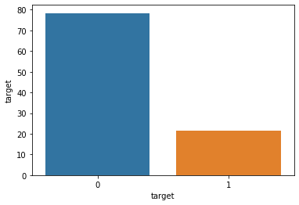

```python
sns.barplot(x="target", y="target", data=df, estimator=lambda x: len(x) / len(df) * 100);
```

```python
print("Percetage of people that have paid: ", round(sum(df["target"]/len(df["target"])),2))
```

[output not shown]

```python
print("Percetage of people that haven't paid: ", round((1-sum(df["target"]/len(df["target"]))),2))
```

[output not shown]

```python
df['target'].value_counts(normalize=True, dropna=False)
```

```
0    0.783726
1    0.216274
Name: target, dtype: float64
```

```python
df.drop("loan_status", axis=1, inplace=True)
```

Let's see how many missing information we have for each column.

```python
nulls = pd.DataFrame(round(df.isnull().sum()/len(df.index) * 100, 2), columns=['null_percent'])
```

```python
nulls.sort_values('null_percent', ascending=False)
```

|  | null_percent |
| --- | --- |
| id | 100.00 |
| url | 100.00 |
| member_id | 100.00 |
| orig_projected_additional_accrued_interest | 99.62 |
| sec_app_mths_since_last_major_derog | 99.48 |
| ... | ... |
| policy_code | 0.00 |
| inq_last_6mths | 0.00 |
| earliest_cr_line | 0.00 |
| delinq_2yrs | 0.00 |
| target | 0.00 |

145 rows × 1 columns

We have a large number of features with a high percentage os NaN, we will deal with this in the next section.

```python
# save to local disk
df.to_csv('../data/loan_target.csv', index=False)
```